# cnn-commented

Name, matrikelnummer

Prioteasa Cristi Andrei, 4740844  
..., ...

#### Introduction

```python
import numpy as np
import matplotlib.pyplot as plt

import torch
import torch.optim as optim
from torch.utils.data import DataLoader

import torchvision.datasets as datasets
import torchvision.transforms as transforms

from torch.nn.functional import conv2d, max_pool2d, cross_entropy

plt.rc("figure", dpi=100)

# device = torch.device("cuda" if torch.cuda.is_available() else "cpu")
device = 'cpu'
print(device)
```

```
cpu
```

```python
TRAIN_BASE_MODEL = True
TRAIN_DROPOUT_MODEL = True
TRAIN_PRELU_MODEL = True
TRAIN_LENET = True
TRAIN_LENET_SHIFT = True

ALL = TRAIN_BASE_MODEL and TRAIN_DROPOUT_MODEL and TRAIN_PRELU_MODEL and TRAIN_LENET and TRAIN_LENET_SHIFT
```

```python
n_epochs = 20
batch_size = 100

# transform images into normalized tensors
transform = transforms.Compose([
    transforms.ToTensor(),
    transforms.Normalize(mean=(0.5,), std=(0.5,))
])

transform_extended = transforms.Compose([
    transforms.ToTensor(),
    transforms.Normalize(mean=(0.5,), std=(0.5,)),
])

train_dataset = datasets.MNIST(
    "./",
    download=True,
    train=True,
    transform=transform,
)

test_dataset = datasets.MNIST(
    "./",
    download=True,
    train=False,
    transform=transform,
)

train_dataloader = DataLoader(
    dataset=train_dataset,
    batch_size=batch_size,
    shuffle=True,
    num_workers=1,
    pin_memory=True,
)

test_dataloader = DataLoader(
    dataset=test_dataset,
    batch_size=batch_size,
    shuffle=False,
    num_workers=1,
    pin_memory=True,
)
```

```python
def init_weights(shape):
    # Kaiming He initialization (a good initialization is important)
    # https://arxiv.org/abs/1502.01852
    std = np.sqrt(2. / shape[0])
    w = torch.randn(size=shape).to(device) * std
    w.requires_grad = True
    return w


def rectify(x):
    # Rectified Linear Unit (ReLU)
    return torch.max(torch.zeros_like(x), x)
```

```python
class RMSprop(optim.Optimizer):
    """
    This is a reduced version of the PyTorch internal RMSprop optimizer
    It serves here as an example
    """
    def __init__(self, params, lr=1e-3, alpha=0.5, eps=1e-8):
        defaults = dict(lr=lr, alpha=alpha, eps=eps)
        super(RMSprop, self).__init__(params, defaults)

    def step(self):
        for group in self.param_groups:
            for p in group['params']:
                grad = p.grad.data.to(device)
                state = self.state[p]

                # state initialization
                if len(state) == 0:
                    state['square_avg'] = torch.zeros_like(p.data)

                square_avg = state['square_avg']
                alpha = group['alpha']

                # update running averages
                square_avg.mul_(alpha).addcmul_(grad, grad, value=1 - alpha)
                avg = square_avg.sqrt().add_(group['eps'])

                # gradient update
                p.data.addcdiv_(grad, avg, value=-group['lr'])
```

```python
# define the neural network
def model(x, w_h, w_h2, w_o):
    h = rectify(x @ w_h)
    h2 = rectify(h @ w_h2)
    pre_softmax = h2 @ w_o
    return pre_softmax
```

```python
if TRAIN_BASE_MODEL:

    # initialize weights
    # input shape is (B, 784)
    w_h = init_weights((784, 625))
    # hidden layer with 625 neurons
    w_h2 = init_weights((625, 625))
    # hidden layer with 625 neurons
    w_o = init_weights((625, 10))
    # output shape is (B, 10)


    optimizer = RMSprop(params=[w_h, w_h2, w_o])

    train_loss = []
    test_loss = []
```

```python
if TRAIN_BASE_MODEL:
    # put this into a training loop over 100 epochs
    for epoch in range(n_epochs + 1):
        train_loss_this_epoch = []
        for idx, batch in enumerate(train_dataloader):
            x, y = batch

            # our model requires flattened input
            x = x.reshape(batch_size, 784).to(device)
            # feed input through model
            noise_py_x = model(x, w_h, w_h2, w_o)

            # reset the gradient
            optimizer.zero_grad()

            # the cross-entropy loss function already contains the softmax
            loss = cross_entropy(noise_py_x, y.to(device), reduction="mean")

            train_loss_this_epoch.append(float(loss))

            # compute the gradient
            loss.backward()
            # update weights
            optimizer.step()

        train_loss.append(np.mean(train_loss_this_epoch))

        # test periodically
        if epoch % 2 == 0:
            print(f"Epoch: {epoch}")
            print(f"Mean Train Loss: {train_loss[-1]:.2e}")
            test_loss_this_epoch = []

            # no need to compute gradients for validation
            with torch.no_grad():
                for idx, batch in enumerate(test_dataloader):
                    x, y = batch
                    x = x.reshape(batch_size, 784).to(device)
                    noise_py_x = model(x, w_h, w_h2, w_o)

                    loss = cross_entropy(noise_py_x, y.to(device), reduction="mean")
                    test_loss_this_epoch.append(float(loss))

            test_loss.append(np.mean(test_loss_this_epoch))

            print(f"Mean Test Loss:  {test_loss[-1]:.2e}")
```

```
Epoch: 0
Mean Train Loss: 3.89e-01
Mean Test Loss:  2.43e-01
Epoch: 2
Mean Train Loss: 2.03e-01
Mean Test Loss:  1.66e-01
Epoch: 4
Mean Train Loss: 1.88e-01
Mean Test Loss:  1.84e-01
Epoch: 6
Mean Train Loss: 1.71e-01
Mean Test Loss:  3.13e-01
Epoch: 8
Mean Train Loss: 1.57e-01
Mean Test Loss:  2.85e-01
Epoch: 10
Mean Train Loss: 1.41e-01
Mean Test Loss:  2.57e-01
Epoch: 12
Mean Train Loss: 1.45e-01
Mean Test Loss:  4.23e-01
Epoch: 14
Mean Train Loss: 1.25e-01
Mean Test Loss:  3.14e-01
Epoch: 16
Mean Train Loss: 1.18e-01
Mean Test Loss:  3.79e-01
Epoch: 18
Mean Train Loss: 1.07e-01
Mean Test Loss:  3.75e-01
Epoch: 20
Mean Train Loss: 9.41e-02
Mean Test Loss:  3.69e-01
```

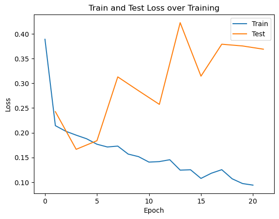

```python
if TRAIN_BASE_MODEL:
    plt.plot(np.arange(n_epochs + 1), train_loss, label="Train")
    plt.plot(np.arange(1, n_epochs + 2, 2), test_loss, label="Test")
    plt.title("Train and Test Loss over Training")
    plt.xlabel("Epoch")
    plt.ylabel("Loss")
    plt.legend()
```

Same result as the solution, but we use a lower number of epochs.

#### Dropout

```python
# def dropout(X,p_drop=0.5):

#     if p_drop > 1:
#         return X

#     mask = torch.bernoulli(torch.ones_like(X) * (1 - p_drop))
#     return mask * X / (1 - p_drop)

# def dropout_layer(X, dropout):
#     assert 0 <= dropout <= 1
#     if dropout == 1: return torch.zeros_like(X)
#     mask = (torch.rand(X.shape) > dropout).float()
#     return mask * X / (1.0 - dropout)

# def dropout(X, p_drop=0.5):
#     if 0 < p_drop < 1:
#         dropout_mask = torch.random.binomial(1, 1 - p_drop, size=X.shape)
#         X_dropout = X * dropout_mask / (1 - p_drop)
#         return X_dropout
#     else:
#         return X

def dropout(X, p_drop=0.5):
    if 0 < p_drop < 1:
        dropout_mask = torch.bernoulli(torch.full(X.shape, 1 - p_drop)).to(X.device)
        X_dropout = X * dropout_mask / (1 - p_drop)
        return X_dropout
    else:
        return X
```

Equivalent implementation to the solution. The solution implementation can be seen in the commented code as well.

```python
def dropout_model(x, w_h, w_h2, w_o, p_drop_input=0,p_drop_hidden=0.2):
    x = dropout(x, p_drop_input)
    h = rectify(x @ w_h)
    h = dropout(h, p_drop_hidden)
    h2 = rectify(h @ w_h2)
    h2 = dropout(h2, p_drop_hidden)
    pre_softmax = h2 @ w_o
    return pre_softmax
```

Implementation as the solution. Chosen params from dropout similar to solution. We used 0 for p_drop_input because we only trained for 20 epochs and it was too much regularization for the model to learn something. We use the same p_drop_hidden=0.2 as the solution.

```python
if TRAIN_DROPOUT_MODEL:
    # initialize weights
    # input shape is (B, 784)
    w_h_drop = init_weights((784, 625))
    # hidden layer with 625 neurons
    w_h2_drop = init_weights((625, 625))
    # hidden layer with 625 neurons
    w_o_drop = init_weights((625, 10))
    # output shape is (B, 10)

    optimizer = RMSprop(params=[w_h_drop, w_h2_drop, w_o_drop])

    train_loss_drop = []
    test_loss_drop = []
```

```python
if TRAIN_DROPOUT_MODEL:
    # put this into a training loop over 100 epochs
    for epoch in range(n_epochs + 1):
        train_loss_this_epoch = []
        for idx, batch in enumerate(train_dataloader):
            x, y = batch

            # our model requires flattened input
            x = x.reshape(batch_size, 784).to(device)
            # feed input through model
            noise_py_x = dropout_model(x, w_h_drop, w_h2_drop, w_o_drop)

            # reset the gradient
            optimizer.zero_grad()

            # the cross-entropy loss function already contains the softmax
            loss = cross_entropy(noise_py_x, y.to(device), reduction="mean")

            train_loss_this_epoch.append(float(loss))

            # compute the gradient
            loss.backward()
            # update weights
            optimizer.step()

        train_loss_drop.append(np.mean(train_loss_this_epoch))

        # test periodically
        if epoch % 2 == 0:
            print(f"Epoch: {epoch}")
            print(f"Mean Train Loss: {train_loss_drop[-1]:.2e}")
            test_loss_this_epoch = []

            # no need to compute gradients for validation
            with torch.no_grad():
                for idx, batch in enumerate(test_dataloader):
                    x, y = batch
                    x = x.reshape(batch_size, 784).to(device)
                    noise_py_x = dropout_model(x, w_h_drop, w_h2_drop, w_o_drop,0,0)

                    loss = cross_entropy(noise_py_x, y.to(device), reduction="mean")
                    test_loss_this_epoch.append(float(loss))

            test_loss_drop.append(np.mean(test_loss_this_epoch))

            print(f"Mean Test Loss:  {test_loss_drop[-1]:.2e}")
```

```
Epoch: 0
Mean Train Loss: 4.56e-01
Mean Test Loss:  1.91e-01
Epoch: 2
Mean Train Loss: 2.66e-01
Mean Test Loss:  2.04e-01
Epoch: 4
Mean Train Loss: 2.69e-01
Mean Test Loss:  1.93e-01
Epoch: 6
Mean Train Loss: 2.70e-01
Mean Test Loss:  1.64e-01
Epoch: 8
Mean Train Loss: 2.67e-01
Mean Test Loss:  2.31e-01
Epoch: 10
Mean Train Loss: 2.78e-01
Mean Test Loss:  2.89e-01
Epoch: 12
Mean Train Loss: 2.57e-01
Mean Test Loss:  2.09e-01
Epoch: 14
Mean Train Loss: 2.54e-01
Mean Test Loss:  2.54e-01
Epoch: 16
Mean Train Loss: 2.57e-01
Mean Test Loss:  1.95e-01
Epoch: 18
Mean Train Loss: 2.56e-01
Mean Test Loss:  2.89e-01
Epoch: 20
Mean Train Loss: 2.57e-01
Mean Test Loss:  2.64e-01
```

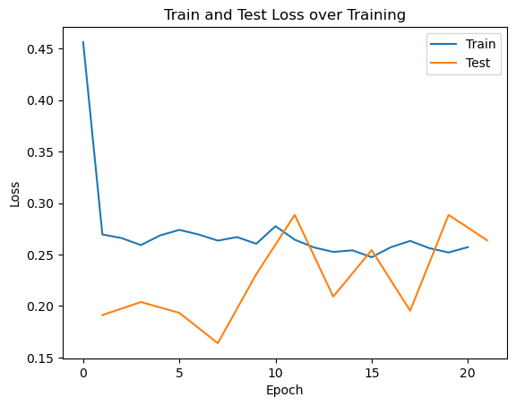

```python
if TRAIN_DROPOUT_MODEL:
    plt.plot(np.arange(n_epochs + 1), train_loss_drop, label="Train")
    plt.plot(np.arange(1, n_epochs + 2, 2), test_loss_drop, label="Test")
    plt.title("Train and Test Loss over Training")
    plt.xlabel("Epoch")
    plt.ylabel("Loss")
    plt.legend()
```

The dropout layer works by randomly deactivating certain neurons in the linear layers (or if applied to the input, deactivating certain features of the input vector). In this way the training load is more evenly distributed among the network, encourages diversity in the learned parameters and helps reduce redundancy i.e. neurons that do not significantly contribute to the performance of the network (cause of their existance can be attributed to overparametrization; see https://arxiv.org/abs/1503.02531, https://arxiv.org/abs/1803.03635).

In our implementation we use all the neurons for the testing to get the best accuracy, so in this sense this is Inverted Dropout not dropout. See: https://stackoverflow.com/questions/54109617/implementing-dropout-from-scratch

A dropout rate of 0.5 seemed to be to big and stopped the model from converging. We try different dropout rates and see that 0.2 offers a good convergence, given the learning rate.

The model still overfits on the test data, but the overfitting is delayed and reduced by using dropout.

```python
if TRAIN_DROPOUT_MODEL and TRAIN_BASE_MODEL:
    ## test error comparation
    print("With dropout: {}".format(test_loss_drop[-1]))
    print("Without dropout: {}".format(test_loss[-1]))
```

```
With dropout: 0.2638609290184118
Without dropout: 0.36894176742001666
```

#### Parametric Relu

```python
def PRelu(X,a):
    assert X.shape == a.shape

    return torch.where(X > 0, X, a*X)

# define the neural network
def prelu_model(x, w_h, w_h2, w_o, a1, a2):
    h = PRelu(x @ w_h,a1)
    h2 = PRelu(h @ w_h2, a2)
    pre_softmax = h2 @ w_o
    return pre_softmax
```

We defined our prelu model without dropout, in order to analyze just the influence of the Prelu layer to the base model. We use the given init_weights function for the initialization of the parameter a, which differs from the given solution by initializing the vectors with random numbers and a calculated std, not zeros. This does not make a big difference.

```python
if TRAIN_PRELU_MODEL:
    # initialize weights
    # input shape is (B, 784)
    w_h_prelu = init_weights((784, 625))
    a1 = init_weights((batch_size,625))
    # hidden layer with 625 neurons
    w_h2_prelu = init_weights((625, 625))
    a2 = init_weights((batch_size,625))
    # hidden layer with 625 neurons
    w_o_prelu = init_weights((625, 10))
    # output shape is (B, 10)

    optimizer = RMSprop(params=[w_h_prelu, w_h2_prelu, w_o_prelu,a1,a2])

    train_loss_prelu = []
    test_loss_prelu = []
```

```python
if TRAIN_PRELU_MODEL:
    # put this into a training loop over 100 epochs
    for epoch in range(n_epochs + 1):
        train_loss_this_epoch = []
        for idx, batch in enumerate(train_dataloader):
            x, y = batch

            # our model requires flattened input
            x = x.reshape(batch_size, 784).to(device)
            # feed input through model
            noise_py_x = prelu_model(x, w_h_prelu, w_h2_prelu, w_o_prelu,a1,a2)

            # reset the gradient
            optimizer.zero_grad()

            # the cross-entropy loss function already contains the softmax
            loss = cross_entropy(noise_py_x, y.to(device), reduction="mean")

            train_loss_this_epoch.append(float(loss))

            # compute the gradient
            loss.backward()
            # update weights
            optimizer.step()

        train_loss_prelu.append(np.mean(train_loss_this_epoch))

        # test periodically
        if epoch % 2 == 0:
            print(f"Epoch: {epoch}")
            print(f"Mean Train Loss: {train_loss_prelu[-1]:.2e}")
            test_loss_this_epoch = []

            # no need to compute gradients for validation
            with torch.no_grad():
                for idx, batch in enumerate(test_dataloader):
                    x, y = batch
                    x = x.reshape(batch_size, 784).to(device)
                    noise_py_x = prelu_model(x, w_h_prelu, w_h2_prelu, w_o_prelu,a1,a2)

                    loss = cross_entropy(noise_py_x, y.to(device), reduction="mean")
                    test_loss_this_epoch.append(float(loss))

            test_loss_prelu.append(np.mean(test_loss_this_epoch))

            print(f"Mean Test Loss:  {test_loss_prelu[-1]:.2e}")
```

```
Epoch: 0
Mean Train Loss: 4.25e-01
Mean Test Loss:  2.94e-01
Epoch: 2
Mean Train Loss: 1.86e-01
Mean Test Loss:  1.77e-01
Epoch: 4
Mean Train Loss: 1.52e-01
Mean Test Loss:  1.56e-01
Epoch: 6
Mean Train Loss: 1.36e-01
Mean Test Loss:  1.68e-01
Epoch: 8
Mean Train Loss: 1.20e-01
Mean Test Loss:  1.76e-01
Epoch: 10
Mean Train Loss: 1.16e-01
Mean Test Loss:  2.46e-01
Epoch: 12
Mean Train Loss: 1.04e-01
Mean Test Loss:  1.95e-01
Epoch: 14
Mean Train Loss: 1.03e-01
Mean Test Loss:  1.73e-01
Epoch: 16
Mean Train Loss: 9.69e-02
Mean Test Loss:  2.28e-01
Epoch: 18
Mean Train Loss: 9.00e-02
Mean Test Loss:  3.27e-01
Epoch: 20
Mean Train Loss: 8.72e-02
Mean Test Loss:  2.15e-01
```

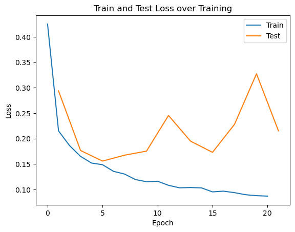

```python
if TRAIN_PRELU_MODEL:
    plt.plot(np.arange(n_epochs + 1), train_loss_prelu, label="Train")
    plt.plot(np.arange(1, n_epochs + 2, 2), test_loss_prelu, label="Test")
    plt.title("Train and Test Loss over Training")
    plt.xlabel("Epoch")
    plt.ylabel("Loss")
    plt.legend()
```

#### Convolutional layers

[figure not shown]

```python
if TRAIN_LENET:
    hyperparams = {
        'length': 3,
        'f': [32,64,128],
        'pic_in': [1,32,64],
        'k_x': [5,5,3],
        'k_y': [5,5,3]
    }

    weight_vectors = [init_weights((hyperparams['f'][i],hyperparams['pic_in'][i],hyperparams['k_x'][i],hyperparams['k_y'][i])) for i in range(3)]

    number_of_output_pixel = 128 # chat gpt answer
    # hidden layer with 625 neurons
    w_h2 = init_weights((number_of_output_pixel, 625))
    # hidden layer with 625 neurons
    w_o = init_weights((625, 10))
    # output shape is (B, 10)

    optimizer = RMSprop(params=[w_h2,w_o,*weight_vectors])

    train_loss_lenet = []
    test_loss_lenet = []
```

```python
def leNet(X,weight_vectors,w_h2,w_o,p_drop_input):
    '''
    x: (batch,1,28,28)
    '''
    conv1 = rectify(conv2d(X,weight_vectors[0]))
    subsampling_layer = max_pool2d(conv1,(2,2))
    out_layer = dropout(subsampling_layer,p_drop_input)

    conv2 = rectify(conv2d(out_layer,weight_vectors[1]))
    subsampling_layer_2 = max_pool2d(conv2,(2,2))
    out_layer_2 = dropout(subsampling_layer_2,p_drop_input)

    conv3 = rectify(conv2d(out_layer_2,weight_vectors[2]))
    subsampling_layer_3 = max_pool2d(conv3,(2,2))
    out_layer_3 = dropout(subsampling_layer_3,p_drop_input)

    # print(out_layer_3.shape)

    flattened_out = out_layer_3.reshape(batch_size,-1)

    # print(flattened_out.shape)

    h2 = rectify(flattened_out @ w_h2)
    pre_softmax = h2 @ w_o

    return pre_softmax
```

Similar implementation as the solution.

```python
def plot_lenet(image,filters):
    '''
    plots:
    - original test image
    - image after 3 filters from the conv1 applied to it (in parallel)
    - filter weights as images
    '''
    # Perform convolution using the selected filters
    conv_results = []
    for i in range(3):
        conv_result = conv2d(image.unsqueeze(0), filters[i].unsqueeze(0))
        conv_results.append(conv_result.cpu().squeeze().detach().numpy())

    # Convert the image and filters to numpy arrays for plotting
    image_np = image.cpu().squeeze().numpy()
    filters_np = filters.detach().cpu().squeeze().numpy()

    print(filters_np.shape)

    # Plot the results
    fig, axs = plt.subplots(3, 3, figsize=(12, 12))


    # Plot the filter weights and convolved images
    for i in range(3):
        # Plot the original image
        axs[i, 0].imshow(image_np, cmap='gray')
        axs[i, 0].set_title("Original Image")


        # Plot filter weights
        axs[i, 1].imshow(filters_np[i], cmap='viridis')
        axs[i, 1].set_title(f"Filter {i + 1} Weights")

        # Plot convolved image
        axs[i, 2].imshow(conv_results[i], cmap='viridis')
        axs[i, 2].set_title(f"Convolution with Filter {i + 1}")

    plt.tight_layout()
    plt.show()
```

Similar plotting function as the solution.

```python
if TRAIN_LENET:
    # put this into a training loop over 100 epochs
    for epoch in range(n_epochs + 1):
        train_loss_this_epoch = []
        for idx, batch in enumerate(train_dataloader):
            x, y = batch

            # our model requires flattened input
            x = x.to(device)
            # feed input through model
            noise_py_x = leNet(x,weight_vectors,w_h2,w_o,0.5)

            # reset the gradient
            optimizer.zero_grad()

            # the cross-entropy loss function already contains the softmax
            loss = cross_entropy(noise_py_x, y.to(device), reduction="mean")

            train_loss_this_epoch.append(float(loss))

            # compute the gradient
            loss.backward()
            # update weights
            optimizer.step()

        train_loss_lenet.append(np.mean(train_loss_this_epoch))

        # test periodically
        if epoch % 2 == 0:
            print(f"Epoch: {epoch}")
            print(f"Mean Train Loss: {train_loss_lenet[-1]:.2e}")
            test_loss_this_epoch = []

            # no need to compute gradients for validation
            with torch.no_grad():
                for idx, batch in enumerate(test_dataloader):
                    x, y = batch
                    x = x.to(device)
                    noise_py_x = leNet(x,weight_vectors,w_h2,w_o,0)

                    loss = cross_entropy(noise_py_x, y.to(device), reduction="mean")
                    test_loss_this_epoch.append(float(loss))

            test_loss_lenet.append(np.mean(test_loss_this_epoch))

            print(f"Mean Test Loss:  {test_loss_lenet[-1]:.2e}")
```

```
Epoch: 0
Mean Train Loss: 5.12e+00
Mean Test Loss:  2.30e+00
Epoch: 2
Mean Train Loss: 2.31e+00
Mean Test Loss:  2.30e+00
Epoch: 4
Mean Train Loss: 2.30e+00
Mean Test Loss:  2.30e+00
Epoch: 6
Mean Train Loss: 2.30e+00
Mean Test Loss:  2.30e+00
Epoch: 8
Mean Train Loss: 2.31e+00
Mean Test Loss:  2.30e+00
Epoch: 10
Mean Train Loss: 2.30e+00
Mean Test Loss:  2.30e+00
Epoch: 12
Mean Train Loss: 2.30e+00
Mean Test Loss:  2.30e+00
Epoch: 14
Mean Train Loss: 2.30e+00
Mean Test Loss:  2.30e+00
Epoch: 16
Mean Train Loss: 2.30e+00
Mean Test Loss:  2.30e+00
Epoch: 18
Mean Train Loss: 2.30e+00
Mean Test Loss:  2.30e+00
Epoch: 20
Mean Train Loss: 2.30e+00
Mean Test Loss:  2.30e+00
```

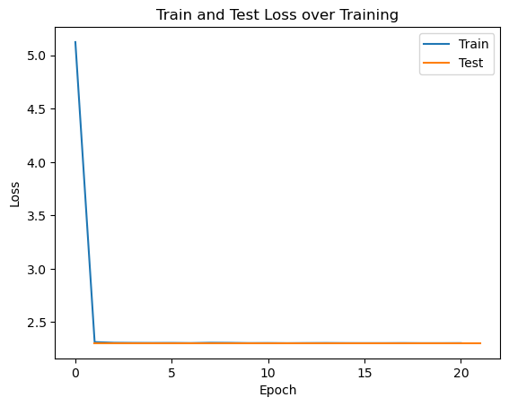

```python
if TRAIN_LENET:
    plt.plot(np.arange(n_epochs + 1), train_loss_lenet, label="Train")
    plt.plot(np.arange(1, n_epochs + 2, 2), test_loss_lenet, label="Test")
    plt.title("Train and Test Loss over Training")
    plt.xlabel("Epoch")
    plt.ylabel("Loss")
    plt.legend()
```

We use a much bigger dropout rate (0.5) and train for only 20 epochs.

```
(3, 5, 5)
```

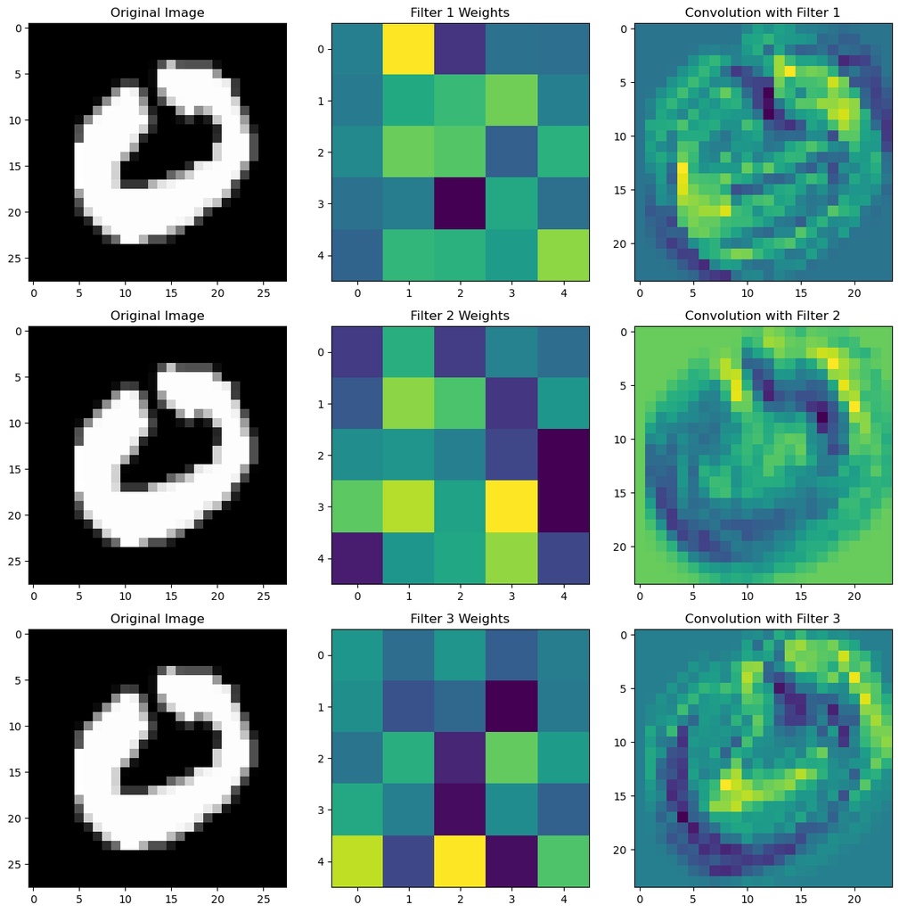

```python
if TRAIN_LENET:
    data_iter = iter(test_dataloader)
    images, labels = next(data_iter)

    image = images[25]
    filters = weight_vectors[0][:3]

    plot_lenet(image.to(device),filters)
```

```python
class RandomLinearShift(object):
    def __init__(self, shift_range=(-0.5, 0.5)):
        self.shift_range = shift_range

    def __call__(self, tensor):
        shift = np.random.uniform(self.shift_range[0], self.shift_range[1])
        return tensor + shift

    def __repr__(self):
        return self.__class__.__name__ + f'(shift_range={self.shift_range})'
```

```python
batch_size = 100

# transform images into normalized tensors
transform = transforms.Compose([
    transforms.ToTensor(),
    transforms.Normalize(mean=(0.5,), std=(0.5,))
])

transform_extended = transforms.Compose([
    transforms.ToTensor(),
    transforms.Normalize(mean=(0.5,), std=(0.5,)),
    RandomLinearShift(shift_range=(-0.5,0.5))
])

train_dataset = datasets.MNIST(
    "./",
    download=True,
    train=True,
    transform=transform,
)

test_dataset = datasets.MNIST(
    "./",
    download=True,
    train=False,
    transform=transforms.Compose([
        transforms.ToTensor(),
        transforms.Normalize(mean=(0.5,), std=(0.5,))
    ]),
)

train_dataloader = DataLoader(
    dataset=train_dataset,
    batch_size=batch_size,
    shuffle=True,
    num_workers=1,
    pin_memory=True,
)

test_dataloader = DataLoader(
    dataset=test_dataset,
    batch_size=batch_size,
    shuffle=False,
    num_workers=1,
    pin_memory=True,
)
```

```python
if TRAIN_LENET_SHIFT:
    hyperparams = {
        'length': 3,
        'f': [32,64,128],
        'pic_in': [1,32,64],
        'k_x': [5,5,3],
        'k_y': [5,5,3]
    }

    weight_vectors = [init_weights((hyperparams['f'][i],hyperparams['pic_in'][i],hyperparams['k_x'][i],hyperparams['k_y'][i])) for i in range(3)]

    number_of_output_pixel = 128 # chat gpt answer
    # hidden layer with 625 neurons
    w_h2 = init_weights((number_of_output_pixel, 625))
    # hidden layer with 625 neurons
    w_o = init_weights((625, 10))
    # output shape is (B, 10)

    optimizer = RMSprop(params=[w_h2,w_o,*weight_vectors])

    train_loss_lenet_shift = []
    test_loss_lenet_shift = []
```

```python
if TRAIN_LENET_SHIFT:
    # put this into a training loop over 100 epochs
    for epoch in range(n_epochs + 1):
        train_loss_this_epoch = []
        for idx, batch in enumerate(train_dataloader):
            x, y = batch

            # our model requires flattened input
            x = x.to(device)
            # feed input through model
            noise_py_x = leNet(x,weight_vectors,w_h2,w_o,0.5)

            # reset the gradient
            optimizer.zero_grad()

            # the cross-entropy loss function already contains the softmax
            loss = cross_entropy(noise_py_x, y.to(device), reduction="mean")

            train_loss_this_epoch.append(float(loss))

            # compute the gradient
            loss.backward()
            # update weights
            optimizer.step()

        train_loss_lenet_shift.append(np.mean(train_loss_this_epoch))

        # test periodically
        if epoch % 2 == 0:
            print(f"Epoch: {epoch}")
            print(f"Mean Train Loss: {train_loss_lenet_shift[-1]:.2e}")
            test_loss_this_epoch = []

            # no need to compute gradients for validation
            with torch.no_grad():
                for idx, batch in enumerate(test_dataloader):
                    x, y = batch
                    x = x.to(device)
                    noise_py_x = leNet(x,weight_vectors,w_h2,w_o,0.0)

                    loss = cross_entropy(noise_py_x, y.to(device), reduction="mean")
                    test_loss_this_epoch.append(float(loss))

            test_loss_lenet_shift.append(np.mean(test_loss_this_epoch))

            print(f"Mean Test Loss:  {test_loss_lenet_shift[-1]:.2e}")
```

```
Epoch: 0
Mean Train Loss: 4.43e+00
Mean Test Loss:  8.79e-01
Epoch: 2
Mean Train Loss: 5.66e-01
Mean Test Loss:  2.98e-01
Epoch: 4
Mean Train Loss: 4.04e-01
Mean Test Loss:  2.32e-01
Epoch: 6
Mean Train Loss: 3.52e-01
Mean Test Loss:  1.75e-01
Epoch: 8
Mean Train Loss: 3.52e-01
Mean Test Loss:  2.67e-01
Epoch: 10
Mean Train Loss: 3.42e-01
Mean Test Loss:  2.10e-01
Epoch: 12
Mean Train Loss: 3.45e-01
Mean Test Loss:  2.03e-01
Epoch: 14
Mean Train Loss: 3.69e-01
Mean Test Loss:  2.45e-01
Epoch: 16
Mean Train Loss: 3.90e-01
Mean Test Loss:  2.46e-01
Epoch: 18
Mean Train Loss: 4.04e-01
Mean Test Loss:  3.16e-01
Epoch: 20
Mean Train Loss: 4.32e-01
Mean Test Loss:  2.63e-01
```

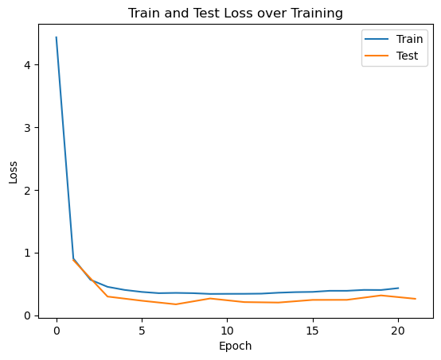

```python
if TRAIN_LENET_SHIFT:
    plt.plot(np.arange(n_epochs + 1), train_loss_lenet_shift, label="Train")
    plt.plot(np.arange(1, n_epochs + 2, 2), test_loss_lenet_shift, label="Test")
    plt.title("Train and Test Loss over Training")
    plt.xlabel("Epoch")
    plt.ylabel("Loss")
    plt.legend()
```

```
(3, 5, 5)
```

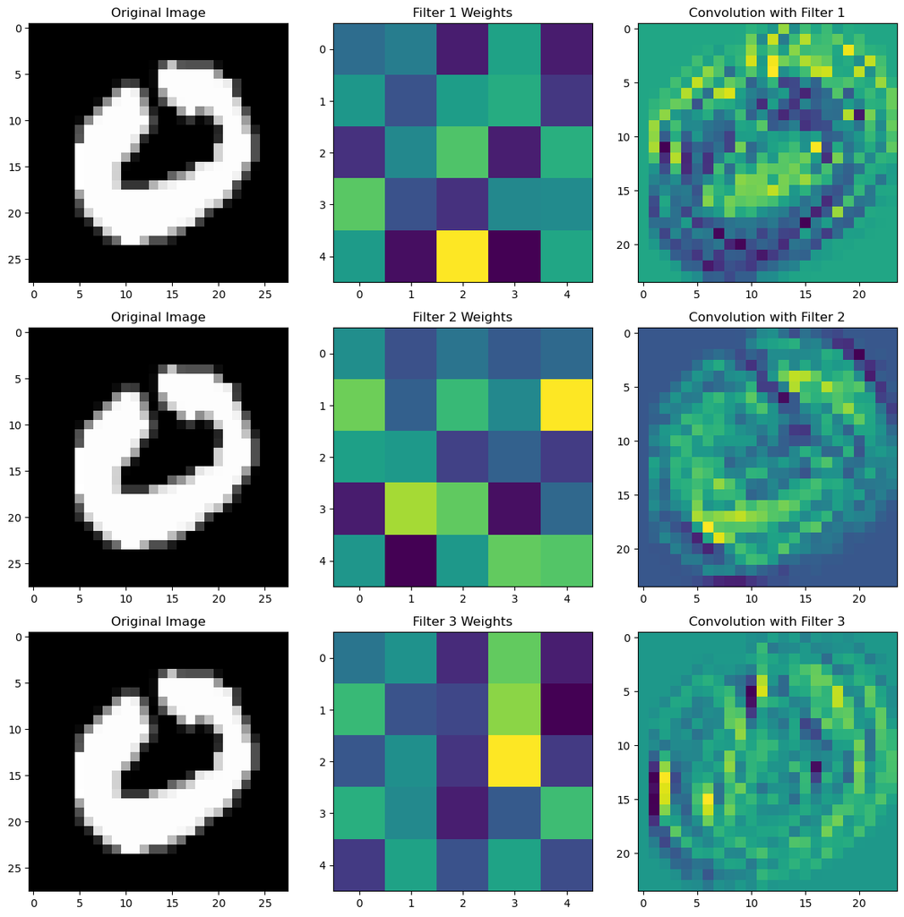

```python
if TRAIN_LENET_SHIFT:
    data_iter = iter(test_dataloader)
    images, labels = next(data_iter)

    image = images[25]
    filters = weight_vectors[0][:3]

    plot_lenet(image.to(device),filters)
```

#### Results table

```python
import pandas as pd

if ALL:

    data = {
        'architecture': ['base', 'dropout', 'prelu', 'lenet', 'lenet + shift'],
        'test_loss': [test_loss[-1],test_loss_drop[-1],test_loss_prelu[-1],test_loss_lenet[-1],test_loss_lenet_shift[-1]],
        'train_loss': [train_loss[-1],train_loss_drop[-1],train_loss_prelu[-1],train_loss_lenet[-1],train_loss_lenet_shift[-1]]
    }

    df = pd.DataFrame(data)

    print("Number of epochs: {}".format(n_epochs))
    print("Learning rate: {}".format(1e-3))
    print("Batch size {}".format(batch_size))
    print("Dropout rate (dropout model + lenet + lenet with shift) {}".format(0.5))
    print(df)
```

[output not shown]